# Rulete ir Moneta

Paulius Kostickis

Monday, March 07, 2016

### Uzduotis Rulete:

Nagrinėkime standartinę kazino ruletę. Kokia tikimybė po 1000 vienodų statymų ant vienos pasirinktos spalvos, bus teigiamas balansas? Raskite apytikslę x reiksmę, kuriai galioja nelygybė P( balansas < x ) = 0.25.

Taisyklės: yra 37 skaičiai ruletės rate, po 18 juodų ir raudonų skaičių ir vienas žalias skaičius. Galima statyti ant pasirinktos juodos arba raudonos spalvos ir jei pasirinkta spalva iškrenta, gauname dvigubą pastatytą sumą atgal. Jei neiškrenta pasirinkta spalva, pralaimime statymą. Jei iskrenta vienintelis žalias skaičius, prarandame pusės statytos sumos.

Taigi sukuriame vienos dienos lošimo sesijos simuliacijos funkciją, kurioje išsukama rulete 1000 kartų:

```r
gamble <- function(){
  x =sample(c(-0.5,-1,1),1000,prob = c(1/37,18/37,18/37),replace=T)
  x=sum(x)
}
```

Naudojant monte carlo metodą bandysime atsakyti į užduotus klausimus, sudarome 10^5 lošimų sesijų:

```r
y <- replicate(10^5,gamble())
```

Tikimybė, kad balansas > 0

```r
p=mean(y>0)
p
```

```
## [1] 0.3321
```

Kad galiotu P ( balansas < x ) = 0.25, x turi būti:

```r
x=quantile(y, 0.25)
unname(x)
```

```
## [1] -34.5
```

### Uzduotis moneta:

Tarkime metama moneta. Jeigu iškrenta herbas, tai laimite 12 EUR. Jeigu skaičius, tai pralošiama 10 EUR. Bus zaidziama n kartu ir gauti rezultatai sumuojami. Kokia tikimybė jums tureti teigiamą balansą po n kartų? Kokis išlosių pasikliautiniai 95% intervalai. Ištirkite tikimybes su skirtingais n, pvz. n=1,2,5,10,20,100. Kaip atrodo balanso tankis? Kai n=100.

Funkcija n išmetimo simuliacija:

```r
flip <- function(n){
    x=sample(c(-10,12),n,replace=T)
    x=sum(x)
}
```

Tirsime lošimo sesiją, kai metama n kartų (t.y. 1,2,5,10,20,100). Naudosime monte carlo metodą ir simuliuosime 10^4 losimų sesijų su n metimų vienoje sesijoje ir viską išsaugau matricoje y.

```r
n=c(1,2,5,10,20,100)
u = numeric(0)
for(i in 1:6){
  a<- replicate(10^4,flip(n[i]))
  u = c(u,a)
}
y=matrix(u, byrow = F, ncol = 6)
head(y)
```

```
##      [,1] [,2] [,3] [,4] [,5] [,6]
## [1,]  -10    2   -6   32   -2  232
## [2,]  -10    2   16   32  -24   34
## [3,]   12   24   16   76   20  -76
## [4,]  -10  -20   60   10   42  188
## [5,]   12    2  -28  -12  108  -32
## [6,]   12   24   16   10  -24  -54
```

Kaip matome, pirmas stulpelis sesijų realizacijos, kai n=1; antras stulpelis, kai n=2 (du kartus mesta moneta sesijoje) ir pan.

Dabar galime gauti gan tikslų tikimybių vektorių, kurio kiekviena pozicija atitinkamai atsako į klausimą kokia tikimybė, kad po sesijos bus teigiamas balansas, kai n=1,2,5,10,20,100.

```r
  p=numeric(0)
  for(i in 1:6){
  p[i]<-mean(y[,i]>0)
  print(paste("kai n=",i," tikimybė teigiamo balanso",p[i],collapse= " "))

}
```

```
## [1] "kai n= 1  tikimybė teigiamo balanso 0.5012"
## [1] "kai n= 2  tikimybė teigiamo balanso 0.7511"
## [1] "kai n= 3  tikimybė teigiamo balanso 0.5089"
## [1] "kai n= 4  tikimybė teigiamo balanso 0.62"
## [1] "kai n= 5  tikimybė teigiamo balanso 0.5837"
## [1] "kai n= 6  tikimybė teigiamo balanso 0.8071"
```

O atitinkamu n=1,2,5,10,20,100 metimų per sesiją laimejimų 95% pasikliautinieji intervalai yra:

```r
g=numeric(0)
for(i in 1:6){
  x=c(quantile(y[,i], 0.025),quantile(y[,i], 0.975))
  g=c("kai n =", i, "  95% intervalas:" ,"[",unname(x[1]),",",unname(x[2]),"]")
  print(paste(g,collapse=" "))
}
```

```
## [1] "kai n = 1   95% intervalas: [ -10 , 12 ]"
## [1] "kai n = 2   95% intervalas: [ -20 , 24 ]"
## [1] "kai n = 3   95% intervalas: [ -50 , 60 ]"
## [1] "kai n = 4   95% intervalas: [ -56 , 76 ]"
## [1] "kai n = 5   95% intervalas: [ -68 , 108 ]"
## [1] "kai n = 6   95% intervalas: [ -120 , 320 ]"
```

Tankio grafikas, kai n= 100 (N=10000 reiškia sesijų skaičių)

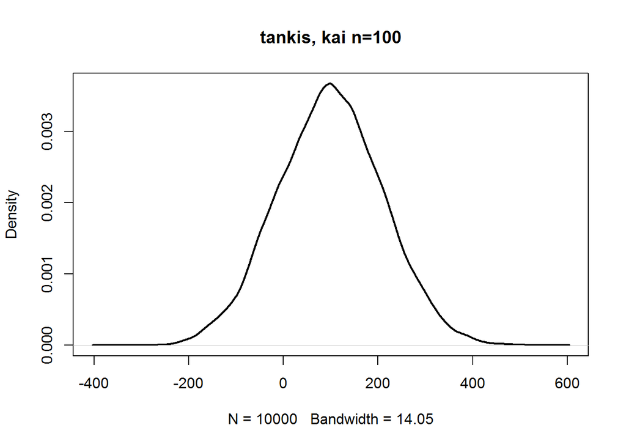

```r
plot(density(y[,6]),main="tankis, kai n=100", lwd = 2)
```